# Report BI 2021/2022 - Grupo 1

## Autores

- Turma: T62
- Grupo: G01/T62
- Autores
  - 20191393 Ana Catarina Quintans - General Manager
  - 20190048 Carlos Chantre - Tech Lead
  - 20181339 Pedro Amaral - Market Analyst

## Introdução

Vivemos em um mundo exponencialmente mais digital e com a digitalização das empresas e da sua informação, a necessidade de análise e tratamento desses mesmos dados é crescente e de imensurável importância na medida em que estes dados podem providenciar imenso valor e vantagens competitivas.

No âmbito da disciplina de Business Intelligence, foi elaborado este trabalho onde o grupo se propõe a estudar um data mart de uma empresa fictícia com dados sobre os seus produtos, vendas, clientes e lojas como forma de extrair a informação relevante para cada um dos diversos departamentos desta empresa, nomeadamente, os departamentos financeiro, de marketing e de gestão da empresa, agregando valor aos dados utilizados através da sua análise com utilização da linguagem R e produzindo um relatório descritivo para cada departamento de estudo.

## Marketing

### Perfil dos clientes

Apresentam-se algumas características dos clientes

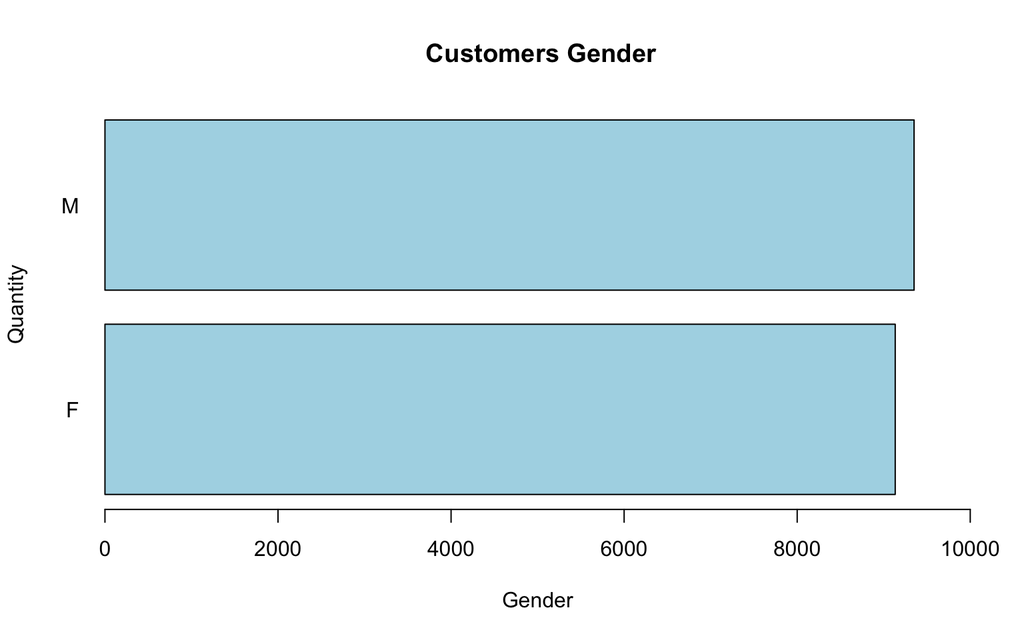

```r
load("customers.Rda")
plot(as.factor(customers$Gender),
     main = " Customers Gender",
     ylab = " Quantity",
     xlab = "Gender",
     xlim = c(0, 10000),
     col= "lightblue",
     horiz = TRUE,
     las = 1)
```

Uma análise, quanto ao género, do perfil dos consumidores. Podemos constatar que existe uma pequena maioria de consumidores do género masculino, no entanto, apenas por uma margém ténue.

- **Estado Civil**

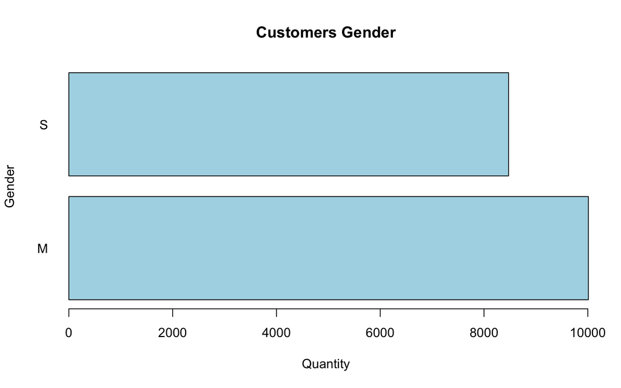

```r
load("customers.Rda")
plot(as.factor(customers$MaritalStatus),
     main = "Customers Gender",
     ylab = "Gender",
     xlab = "Quantity",
     col= "lightblue",
     horiz = TRUE,
     las = 1)
```

Uma análise, quanto ao estado civil, do perfil dos consumidores, pode constatar-se que existe uma maioria de consumidores casados, face aos solteiros.

- **Recomendações**

### Por Categoria X Quantidades

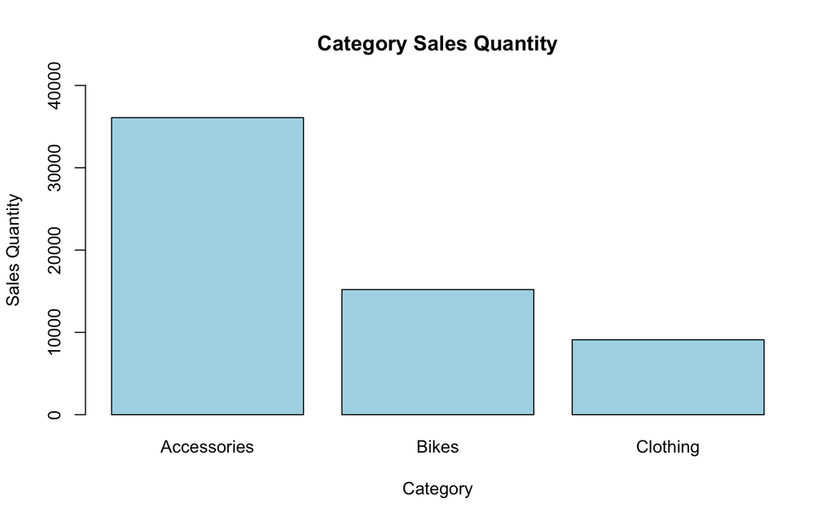

```r
load("sales_product.Rda")
plot(as.factor(sales_product$Category),
     main = "Category Sales Quantity",
     ylab = "Sales Quantity",
     xlab = "Category",
     ylim = c(0, 40000),
     col = "lightblue")
```

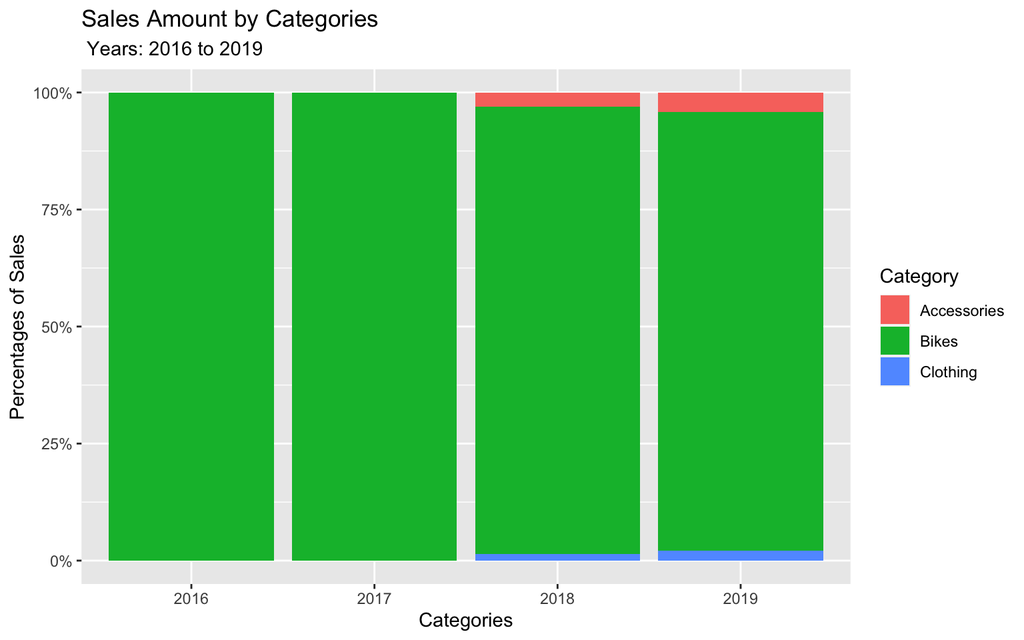

```r
load("sales_av.Rda")
accs_sales_amount <- aggregate(SalesAmount ~ Category + salesYear, data = sales_av,
                                FUN = sum, na.rm = TRUE)

sales_amt_bar <-
    ggplot(accs_sales_amount, aes(fill = Category, x = salesYear, y = SalesAmount/10^6)) +
    geom_bar(position = "fill", stat = "identity") +
    labs(title = "Sales Amount by Categories",
         subtitle = " Years: 2016 to 2019",
         x = "Categories",
         y = "Percentages of Sales") +
    scale_y_continuous(labels = scales::percent)

sales_amt_bar
```

As categorias mais vendidas ao longo do período de 2016 - 2019, consistem na categoria bicicletas. Em 2018, começou-se a vender outras categorias de produtos, nomeadamente, roupas e acessórios. Ambas as categorias, apesar de ainda serem pouco transacionáveis, cresceram.

#### Os novos produtos estão a vender mais ou menos que os anteriores?

### Região

#### Onde é que se vendeu mais?

#### Em que alturas é que se vende mais? Existe sazonalidade?

## Departamento de Vendas

### Análise de vendas por quarter e por ano

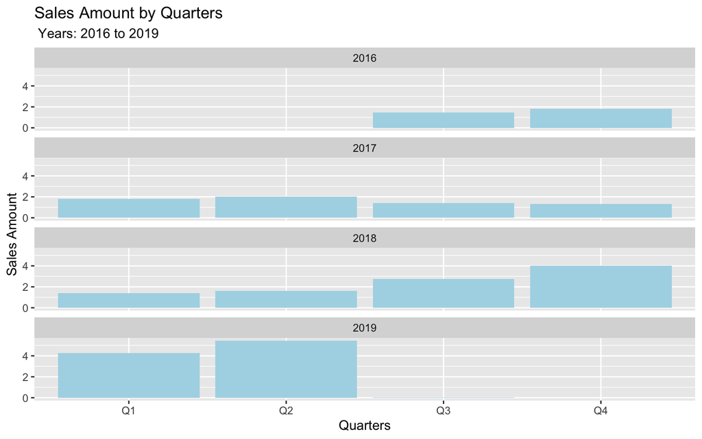

Não existem dados de transações relativos aos 2 primeiros quarters de 2016 e os dois últimos de 2019. Existem flutuações entre quarters, sendo a tendência do volume de vendas de crescimento. É notável que o período entre o Q3- 2016 e o Q2- 2017, foi marcado por um crescimento, enquanto que no mesmo período dos anos seguintes (Q3- 2017 a Q2-2018), sofreu um decréscimo do volume de vendas. Esta tendência inverteu-se no período seguinte, sendo registado um crescimento. Acreditamos que, poderá existir um padrão de sazonalidade, que caso se repita, se refletirá num decréscimo do volume de vendas no próximo ano. Deverá existir um controlo mais rigoroso do volume de vendas para que este padrão possa ser identificado antecipadamente.

### Por frequência de vendas de modo a saber períodos de tempo em que houve mais ativididade

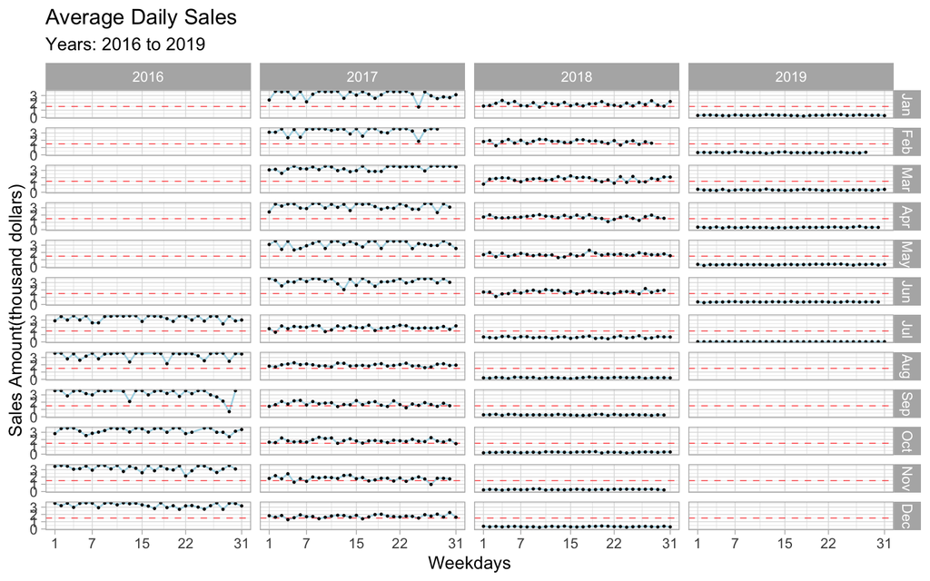

## Departamento Financeiro

### Produto

#### Saber quais são os produtos com maior rentabilidade?

# Apêndice

## Dicionário do **Data Mart**

## 1.`calendar`

Informação de calendário.

- **ID**: Constitui-se como a Surrogate Key (chave artificial).
- **Date**: Contempla as datas ( dia, mês e ano) em que se realizaram transações (*date*)
- **DayNumberOfWeek**:Identifica numericamente o dia da semana. (*numeric*)
- **DayName**: Identifica textualmente o dia da semana. (*string*)
- **MonthName**: Identifica textualmente o mês.(*string*)
- **MonthNumberOfYear**: Identifica o mês numericamente.(*numeric*)
- **DayNumberOfYear**: Identifica o dia do ano num formato de 365 dias. (*numeric*)
- **WeekNumberOfYear**: Identifica a semana numericamente.(*numeric*)
- **CalendarQuarter**: Refere o trimestre em que se realizou a transação. (*numeric*)
- **CalendarYear**: Refere o ano.(*numeric*)
- **DayNumberOfMonth**: Identifica o dia do mês.(*numeric*)

## 2.`product`

Informação sobre o produto.

- **ProductKey**: Chave que identifica o produto (*factor*).
- **ProductSubCategoryKey**: Chave que identifica a sub-categoria do produto (*factor*).
- **ProductName**: Nome do produto.(*string*)
- **StandarCost**: Custo de fabrico. (*numeric*)
- **Color**: Cor do produto. (*string*)
- **SafetyStockLevel**: Stock mínimo.(*numeric*)
- **ListPrice**: Preço de venda dos produtos. (*numeric*)
- **Size**: Tamanho do produto.(*numeric*)
- **DaysToManufacture**: Dias para produzir.(*numeric*)
- **DealerPrice**: Preço de venda para revendedores.(*numeric*)
- **Class**: Classe de produto.(*string*)
- **ModelName**: Nome do modelo do produto.(*string*)
- **Description**: Descrição do produto. (*string*)
- **Status**: Disponibilidade para vender.(*string*)
- **SubCategory**: Sub-categoria. (*string*)
- **Category**: Categoria. (*string*)
- **StartDate**: Desde quando o produto está disponível para vender.(*date*)
- **EndDate**: Desde quando o produto deixou de estar disponivel para venda. (*date*)

## 3.`productCategory`

Informação sobre a categoria do produto.

- **ProductCategoryKey**: Chave que identifica univocamente o produto. (*factor*)
- **EnglishProductCategoryName**: Nome da categoria do produto em Inglês.(*string*)
- **SpanishProductCategoryName**: Nome da categoria do produto em Espanhol.(*string*)
- **FrenchProductCategoryName**: Nome da categoria do produto em Francês.(*string*)

## 4.`productSubCategory`

Informação sobre a sub-categoria do produto.

- **ProductCategoryKey**: Chave que identifica univocamente o produto. (*factor*)
- **ProductSubCategoryKey**: Chave que identifica a sub-categoria do produto (*factor*).
- **EnglishProductSubCategoryName**: Nome da sub-categoria do produto em Inglês.(*string*)
- **SpanishProductSubCategoryName**: Nome da sub-categoria do produto em Espanhol.(string_)
- **FrenchProductSubCategoryName**: Nome da sub-categoria do produto em Francês. (*string*)

## 5.`customers`

Informação sobre os clientes.

- **CustomerKey**: Chave que identifica o cliente.(*factor*)
- **GeographyKey**: Chave que identifica a cidade/código-postal do cliente.(*factor*)
- **Name**: Nome do cliente.(*string*)
- **BirthDate**: Data de nascimento do cliente.(*date*)
- **MaritalStatus**: Estado-civil do cliente.(*string*)
- **Gender**: Género do Cliente. (*string*)
- **YearlyIncome**: Nível de rendimento do cliente.(*numeric*)
- **NumberChildrenAtHome**: Número de crianças do cliente.(*numeric*)
- **Occupation**: Profissão do cliente.(*string*)
- **HouseOwnerFlag**: Se o cliente é proprietário ou não de habitação. (*numeric*)
- **NumberCarsOwned**: Quantos carros cliente possui.(*numeric*)
- **AddressLine**: Morada do cliente. (*string*)
- **Phone**: Número de telefone do cliente. (*numeric*)
- **DateFirstPurchase**: Data da primeira compra. (*date*)

## 6.`territory`

Informação geográfica.

- **Territory Key**: Chave que identifica o território. (*factor*)
- **Region**: Região. (*string*)
- **Country**: País. (*string*)
- **Group**: Região económica. (*string*)

## 7.`factsales`

Tabela de factos [Vendas]

- **OrderDateKey**: Chave que identifica a data da compra.(*factor*)
- **ProductKey**: Chave que identifica o produto (*factor*).
- **CustomerKey**: Chave que identifica o cliente.(*factor*)
- **SalesTerritoryKey**: Chave que identifica o território onde se realizou a compra.(*factor*)
- **SalesOrderNumber**: Número que identifica a venda.(*numeric*)
- **SalesOrderLineNumber**: Número que identifica as transações numa venda. (*string*)
- **OrderQuantity**: Quantidade transacionada. (*numeric*)
- **UnitPrice**: Preço unitário. (*numeric*)
- **ProductStandardCost**: O custo do produto para a empresa. (*numeric*)
- **SalesAmount**: Preço da transação.(*numeric*)
- **TaxAmt**: Imposto sobre a venda. (*numeric*)
- **Freight**: Custo de envio. (*numeric*)
- **RegionMonthID**: Informação sobre quando (mês) foi realizada a venda e em que região. (*factor*)